# Popular Songs Statistical Analysis

Allen Lau

2022-10-13

```r
#Loading R Packages
library(statsr)
library(dplyr)
library(ggplot2)
library(fitdistrplus)
```

## Spotify All Time Top 2000 Songs Analysis

**1. Data Set**

Dataset Info:

1. Source: https://www.kaggle.com/datasets/iamsumat/spotify-top-2000s-mega-dataset

   ```r
   #Import CSV File and store data frame in variable df
   df <- read.csv("Spotify-2000.csv")

   #Display the first 5 rows to confirm import looks correct
   head(df, n = 5)
   ```

   ```
   ##   Index                  Title            Artist           Top.Genre Year
   ## 1     1                Sunrise       Norah Jones     adult standards 2004
   ## 2     2            Black Night       Deep Purple          album rock 2000
   ## 3     3         Clint Eastwood          Gorillaz alternative hip hop 2001
   ## 4     4          The Pretender      Foo Fighters   alternative metal 2007
   ## 5     5 Waitin' On A Sunny Day Bruce Springsteen        classic rock 2002
   ##   Beats.Per.Minute..BPM. Energy Danceability Loudness..dB. Liveness Valence
   ## 1                    157     30           53           -14       11      68
   ## 2                    135     79           50           -11       17      81
   ## 3                    168     69           66            -9        7      52
   ## 4                    173     96           43            -4        3      37
   ## 5                    106     82           58            -5       10      87
   ##   Length..Duration. Acousticness Speechiness Popularity
   ## 1               201           94           3         71
   ## 2               207           17           7         39
   ## 3               341            2          17         69
   ## 4               269            0           4         76
   ## 5               256            1           3         59
   ```

2. Contents:

   ```r
   #Number of variables in the data set
   ncol(df)
   ```

   ```
   ## [1] 15
   ```

   ```r
   #Number of entries in the data set
   nrow(df)
   ```

   ```
   ## [1] 1994
   ```

3. Interest/importance in data set:  
   Music is an important aspect of culture and has been a part of human history for centuries. It can play an important part in things like social gatherings, religion, and storytelling. With the invention of music streaming services, like Spotify, we now have easy access to large amounts of data that can be investigated to understand aspects of human nature and culture.
4. Answers to questions to discover:
   1. Is the popularity of the song related to the energy and danceability of the song?  
      Expectation: My expectation is that more energetic and danceable songs are more popular.  
      Discovery: More of the top 2000 Spotify songs are energetic, so we could correlate the popularity of the song to the energy. In contrast, there is not a larger number of popular songs that have higher danceability.
   2. Is the popularity of the song related to the release date of the song?  
      Expectation: My expectation is that it is related to the release date of the song. The newer the song, the more likely it is to be popular.  
      Discovery: From part 7, we conducted in Hypothesis test, which resulted in us rejecting the null hypothesis of there being no difference in the average popularity value between recent and older songs. We can conclude that there is some relationship between the release date and popularity. This would require more analysis.
   3. Is the popularity of the song related to the speechiness, or the more spoken words the song contains?  
      Expectation: My expectation is that songs with less spoken words are more popular.  
      Discovery: We do see that there are very few top songs that have high speechiness.

**2. Visualization**

Variables of interest:

1. Energy - Higher values indicate more energetic songs
2. Danceability - Higher values indicate that it is easier to dance to the song
3. Speechiness - Higher values indicate more spoken words in the song
1. Histogram, Cumulative Relative Frequency and QQ Plot
1. Energy

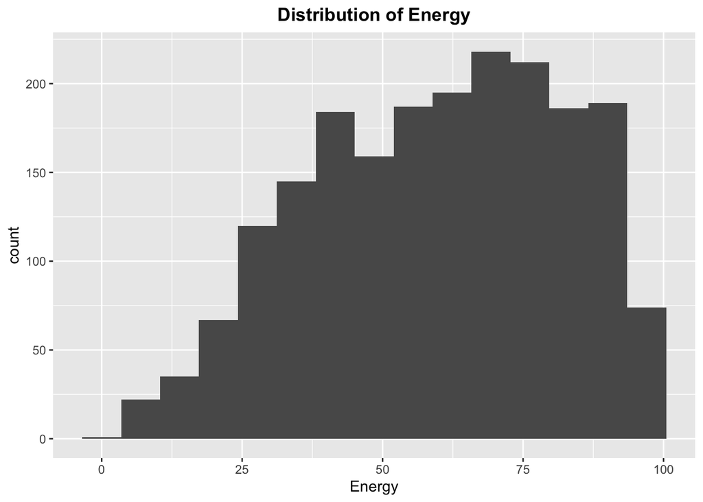

   ```r
   #Energy: Histogram
   ggplot(data = df, aes(x = Energy)) +
     geom_histogram(bins = 15) +
     ggtitle("Distribution of Energy") +
     theme(plot.title = element_text(hjust = 0.5)) +
     theme(plot.title = element_text(face="bold"))
   ```

   ```r
   #Determine range of energy to determine breaks for cum. rel. freq. plot
   range(df$Energy)
   ```

   ```
   ## [1]   3 100
   ```

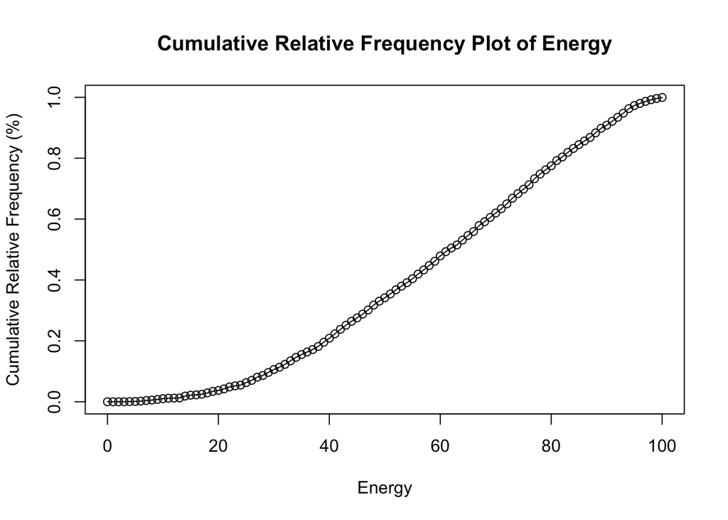

   ```r
   #Energy: Cumulative Relative Frequency
   breaks <- seq(0,100,1)
   energy.cut <- cut(df$Energy, breaks, right=FALSE)
   energy.freq <- table(energy.cut)
   energy.cumfreq <- cumsum(energy.freq)
   energy.cumrelfreq <- energy.cumfreq / nrow(df)
   cumrelfreq0_energy <- c(0, energy.cumrelfreq)
   plot(breaks, cumrelfreq0_energy, main = "Cumulative Relative Frequency Plot of Energy", xlab = "Energy", ylab = "Cumulative Relative Frequency (%)")
   lines(breaks, cumrelfreq0_energy)
   ```

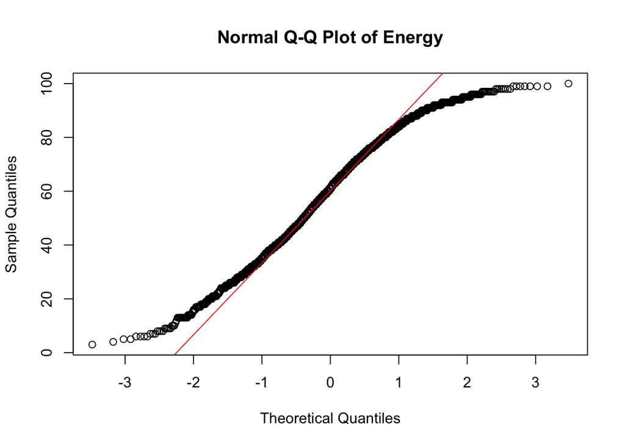

   ```r
   #Energy: QQ Plot
   qqnorm(df$Energy, main="Normal Q-Q Plot of Energy")
   qqline(df$Energy, col = "red")
   ```

2. Danceability

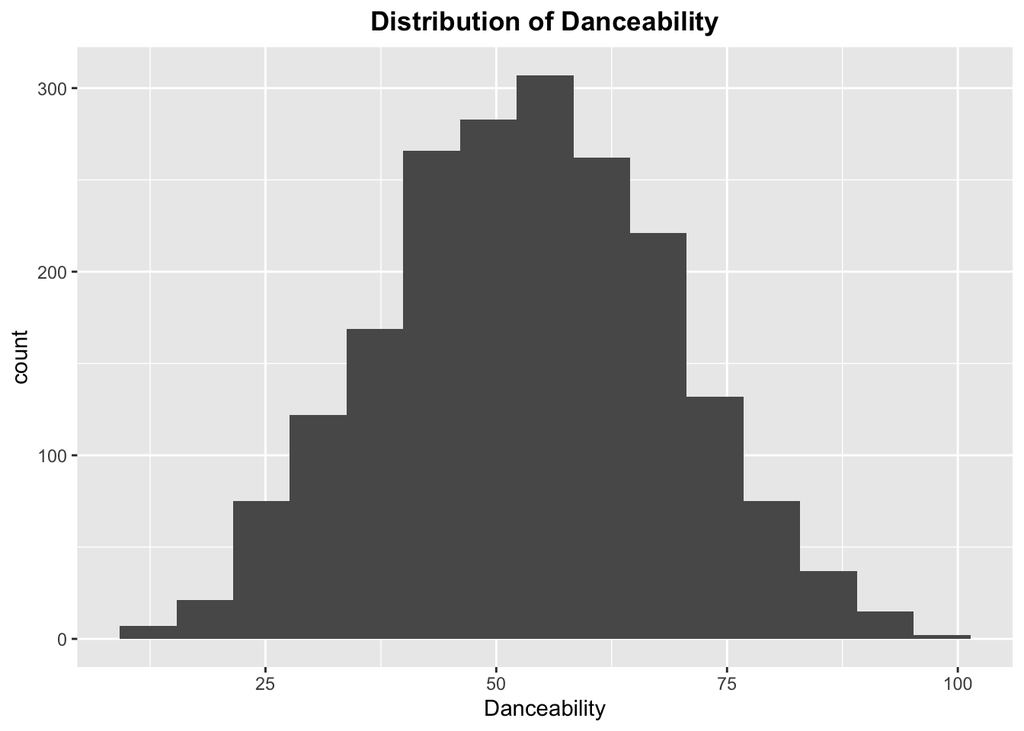

   ```r
   #Danceability: Histogram
   ggplot(data = df, aes(x = Danceability)) +
     geom_histogram(bins = 15) +
     ggtitle("Distribution of Danceability") +
     theme(plot.title = element_text(hjust = 0.5)) +
     theme(plot.title = element_text(face="bold"))
   ```

   ```r
   #Determine range of danceability to determine breaks for cum. rel. freq. plot
   range(df$Danceability)
   ```

   ```
   ## [1] 10 96
   ```

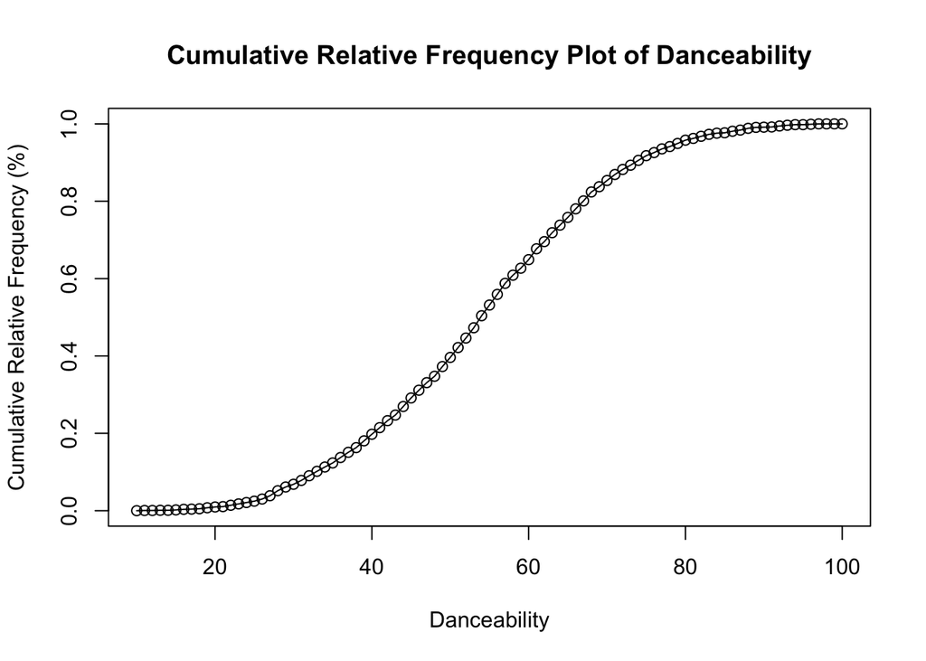

   ```r
   #Danceability: Cumulative Relative Frequency
   breaks <- seq(10,100,1)
   dance.cut <- cut(df$Danceability, breaks, right=FALSE)
   dance.freq <- table(dance.cut)
   dance.cumfreq <- cumsum(dance.freq)
   dance.cumrelfreq <- dance.cumfreq / nrow(df)
   cumrelfreq0_dance <- c(0, dance.cumrelfreq)
   plot(breaks, cumrelfreq0_dance, main = "Cumulative Relative Frequency Plot of Danceability", xlab = "Danceability", ylab = "Cumulative Relative Frequency (%)")
   lines(breaks, cumrelfreq0_dance)
   ```

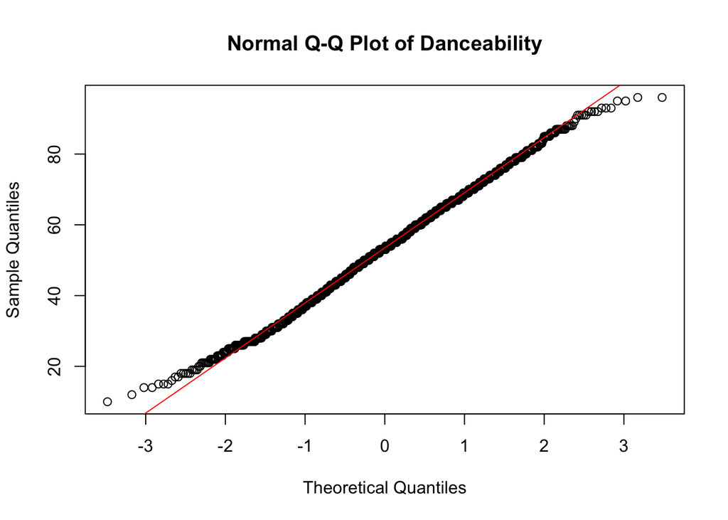

   ```r
   #Danceability: QQ Plot
   qqnorm(df$Danceability, main="Normal Q-Q Plot of Danceability")
   qqline(df$Danceability, col = "red")
   ```

3. Speechiness

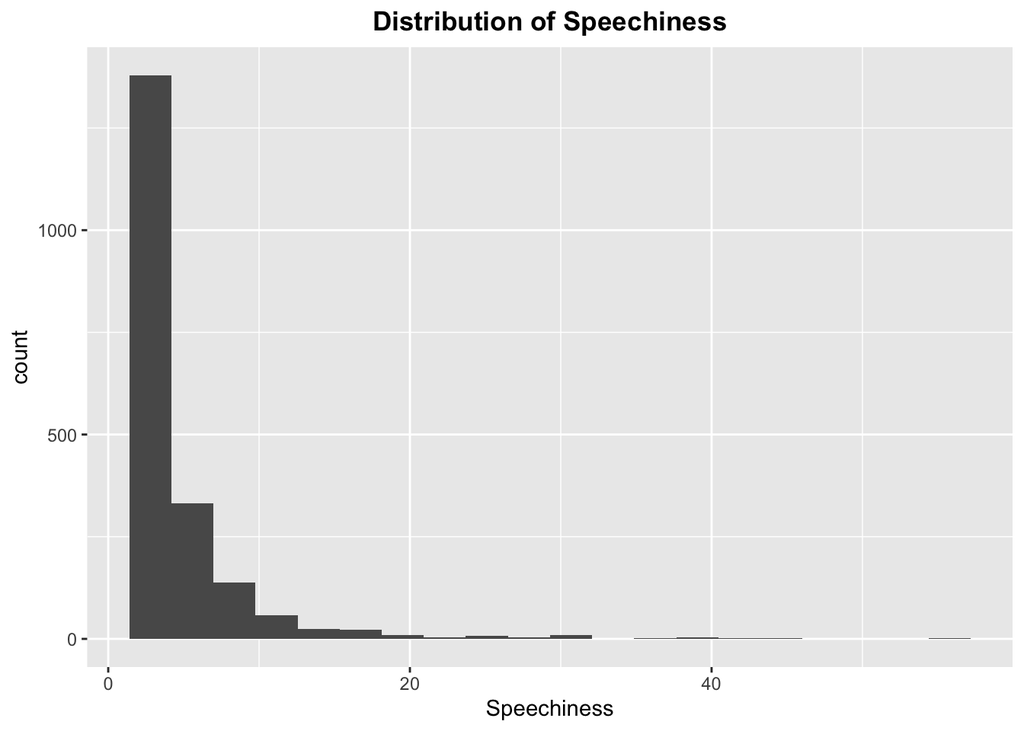

   ```r
   #Speechiness: Histogram
   ggplot(data = df, aes(x = Speechiness)) +
     geom_histogram(bins = 20) +
     ggtitle("Distribution of Speechiness") +
     theme(plot.title = element_text(hjust = 0.5)) +
     theme(plot.title = element_text(face="bold"))
   ```

   ```r
   #Determine range of Speechiness to determine breaks for cum. rel. freq. plot
   range(df$Speechiness)
   ```

   ```
   ## [1]  2 55
   ```

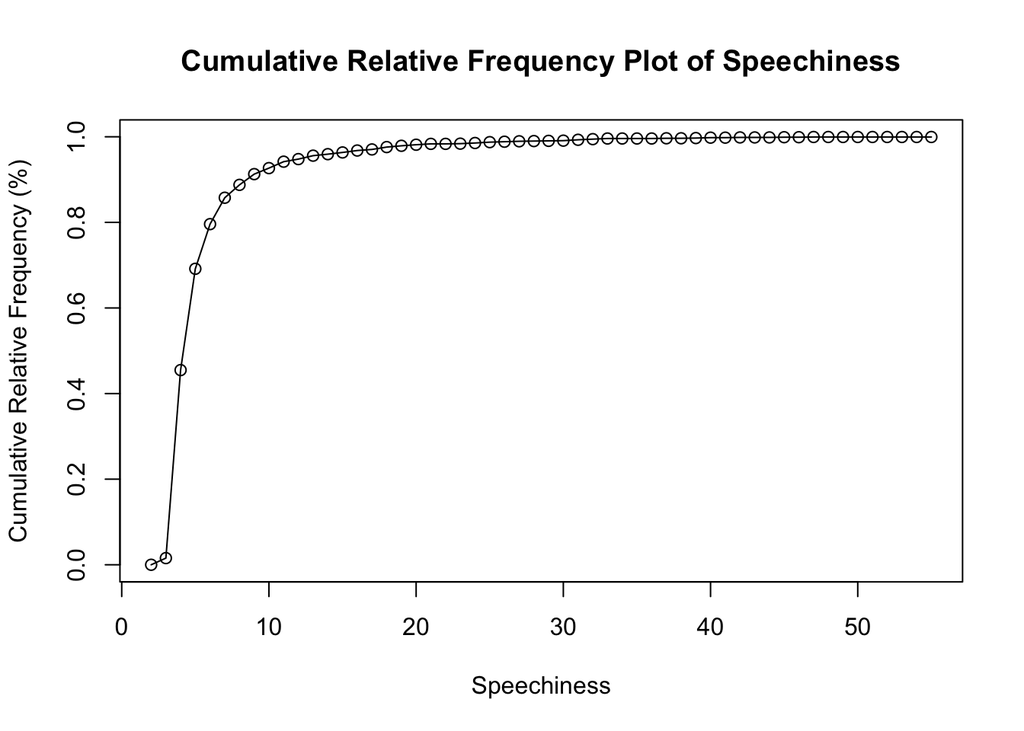

   ```r
   #Speechiness: Cumulative Relative Frequency
   breaks <- seq(2,55,1)
   Speechiness.cut <- cut(df$Speechiness, breaks, right=FALSE)
   Speechiness.freq <- table(Speechiness.cut)
   Speechiness.cumfreq <- cumsum(Speechiness.freq)
   Speechiness.cumrelfreq <- Speechiness.cumfreq / nrow(df)
   cumrelfreq0_Speechiness <- c(0, Speechiness.cumrelfreq)
   plot(breaks, cumrelfreq0_Speechiness, main = "Cumulative Relative Frequency Plot of Speechiness", xlab = "Speechiness", ylab = "Cumulative Relative Frequency (%)")
   lines(breaks, cumrelfreq0_Speechiness)
   ```

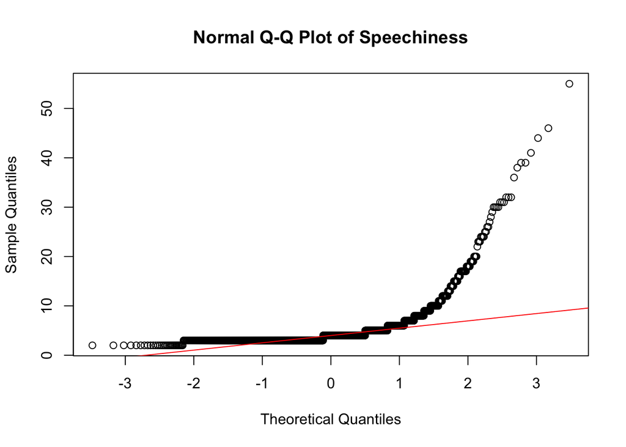

   ```r
   #Speechiness: QQ Plot
   qqnorm(df$Speechiness, main="Normal Q-Q Plot of Speechiness")
   qqline(df$Speechiness, col = "red")
   ```

2. Approximately normal histograms  
   Yes. Looking at the distribution of Danceability, we can say that it is approximately normal. This is also seen in the QQ plot, where the majority of points are on the line with some minor deviations along the tails.

**3. Point Estimates**

1. Sample mean, median, mode, variance, standard deviation

```r
#Function to determine mode
mode <- function(x) {
  uniqueVal <- unique(x)
  uniqueVal[which.max(tabulate(match(x, uniqueVal)))]
}
```

1. Energy

   ```r
   #Energy: mean, median, variance, standard deviation
   df %>%
     summarise(sample_mu = mean(df$Energy),
               sample_med = median(df$Energy),
               sample_mode = mode(df$Energy),
               sample_var = var(df$Energy),
               sample_sd = sd(df$Energy))
   ```

   ```
   ##   sample_mu sample_med sample_mode sample_var sample_sd
   ## 1  59.67954         61          76    490.814  22.15432
   ```

2. Danceability

   ```r
   #Danceability: mean, median, variance, standard deviation
   df %>%
     summarise(sample_mu = mean(df$Danceability),
               sample_med = median(df$Danceability),
               sample_mode = mode(df$Danceability),
               sample_var = var(df$Danceability),
               sample_sd = sd(df$Danceability))
   ```

   ```
   ##   sample_mu sample_med sample_mode sample_var sample_sd
   ## 1  53.23821         53          53   235.6688  15.35151
   ```

3. Speechiness

   ```r
   #Speechiness: mean, median, variance, standard deviation
   df %>%
     summarise(sample_mu = mean(df$Speechiness),
               sample_med = median(df$Speechiness),
               sample_mode = mode(df$Speechiness),
               sample_var = var(df$Speechiness),
               sample_sd = sd(df$Speechiness))
   ```

   ```
   ##   sample_mu sample_med sample_mode sample_var sample_sd
   ## 1  4.994985          4           3   19.37378  4.401566
   ```

2. Proportion of data within 1.5 IQR

```r
#Function to determine proportion of data values that lies within 1.5IQR
data_within1_5IQR <- function(x,lbound,ubound){
  length(x[(x>lbound)&(x<ubound)])/length(df$Energy)
}
```

1. Energy

   ```r
   #Proportion of data within 1.5IQR for Energy
   lowerBound = quantile(df$Energy,0.25) - 1.5*IQR(df$Energy)
   upperBound = quantile(df$Energy,0.75) + 1.5*IQR(df$Energy)
   data_within1_5IQR(df$Energy,lowerBound,upperBound)
   ```

   ```
   ## [1] 1
   ```

2. Danceability

   ```r
   #Proportion of data within 1.5IQR for Danceability
   lowerBound = quantile(df$Danceability,0.25) - 1.5*IQR(df$Danceability)
   upperBound = quantile(df$Danceability,0.75) + 1.5*IQR(df$Danceability)
   data_within1_5IQR(df$Danceability,lowerBound,upperBound)
   ```

   ```
   ## [1] 0.9984955
   ```

3. Speechiness

   ```r
   #Proportion of data within 1.5IQR for Speechiness
   lowerBound = quantile(df$Speechiness,0.25) - 1.5*IQR(df$Speechiness)
   upperBound = quantile(df$Speechiness,0.75) + 1.5*IQR(df$Speechiness)
   data_within1_5IQR(df$Speechiness,lowerBound,upperBound)
   ```

   ```
   ## [1] 0.887663
   ```

3. Assuming population variance is the same as sample variance, construct 95% confidence interval for the population mean based on the entire data set and on the proportion determined in b. Are they different?
1. Energy

   ```r
   # critical value for a 95% confidence interval
   z_star_95 <- qnorm(0.975)

   # Confidence Interval for population mean based on the entire data set and on the portion determined in b.
   df %>%
     summarise(lower = mean(df$Energy) - z_star_95 * (sd(df$Energy) / sqrt(length(df$Energy))),
               upper = mean(df$Energy) + z_star_95 * (sd(df$Energy) / sqrt(length(df$Energy))))
   ```

   ```
   ##      lower    upper
   ## 1 58.70714 60.65194
   ```

   From part b, the entire population of the data set is included within 1.5IQR, so there will be one CI calculation for both the population and sample; therefore, they are not different.
2. Danceability

   ```r
   # 95% Confidence Interval for population mean based on the entire data set
   df %>%
     summarise(lower = mean(df$Danceability) - z_star_95 * (sd(df$Danceability) / sqrt(length(df$Danceability))),
               upper = mean(df$Danceability) + z_star_95 * (sd(df$Danceability) / sqrt(length(df$Danceability))))
   ```

   ```
   ##      lower    upper
   ## 1 52.56441 53.91202
   ```

   ```r
   # 95% Confidence Interval for population mean based on the portion determined in b
   lowerBound = quantile(df$Danceability,0.25) - 1.5*IQR(df$Danceability)
   upperBound = quantile(df$Danceability,0.75) + 1.5*IQR(df$Danceability)
   df_sD <- df %>% filter((Danceability>lowerBound)&(Danceability<upperBound))
   df_sD %>%
     summarise(lower = mean(df_sD$Danceability) - z_star_95 * (sd(df$Danceability) / sqrt(length(df_sD$Danceability))),
               upper = mean(df_sD$Danceability) + z_star_95 * (sd(df$Danceability) / sqrt(length(df_sD$Danceability))))
   ```

   ```
   ##      lower    upper
   ## 1 52.54266 53.89129
   ```

   The 95% confidence intervals are slightly different between the CI calculated on the entire data set and on the portion within 1.5IQR. This is due to the changes that occur to the mean and number of values that result from removing the outliers from the data set. For Danceability, since the proportion of data values that lies within 1.5IQR is 0.998, there will only be very slight changes to the 95% CI calculation.
3. Speechiness

   ```r
   # 95% Confidence Interval for population mean based on the entire data set
   df %>%
     summarise(lower = mean(df$Speechiness) - z_star_95 * (sd(df$Speechiness) / sqrt(length(df$Speechiness))),
               upper = mean(df$Speechiness) + z_star_95 * (sd(df$Speechiness) / sqrt(length(df$Speechiness))))
   ```

   ```
   ##      lower    upper
   ## 1 4.801791 5.188179
   ```

   ```r
   # 95% Confidence Interval for population mean based on the portion determined in b
   lowerBound = quantile(df$Speechiness,0.25) - 1.5*IQR(df$Speechiness)
   upperBound = quantile(df$Speechiness,0.75) + 1.5*IQR(df$Speechiness)
   df_sS <- df %>% filter((Speechiness>lowerBound)&(Speechiness<upperBound))
   df_sS %>%
     summarise(lower = mean(df_sS$Speechiness) - z_star_95 * (sd(df$Speechiness) / sqrt(length(df_sS$Speechiness))),
               upper = mean(df_sS$Speechiness) + z_star_95 * (sd(df$Speechiness) / sqrt(length(df_sS$Speechiness))))
   ```

   ```
   ##      lower    upper
   ## 1 3.623194 4.033303
   ```

   The 95% confidence intervals are different between the CI calculated on the entire data set and on the proportion within 1.5IQR. Since the proportion of data values that lies within 1.5IQR for speechiness is 0.888, there will be more significant differences in the mean and number of values that are used to calculate the CI, when compared to the danceability calculations.
4. Assuming population variance is unknown, construct 95% confidence interval for the population mean. Is it different from CI computed in part c.
1. Energy

   ```r
   # t-critical value for a 95% confidence interval
   t_star_95 <- qt(0.975, df = length(df$Energy) - 1)

   #95% CI for population mean, assuming population variance is unknown
   df %>%
     summarise(lower = mean(df$Energy) - t_star_95 * (sd(df$Energy) / sqrt(length(df$Energy))),
               upper = mean(df$Energy) + t_star_95 * (sd(df$Energy) / sqrt(length(df$Energy))))
   ```

   ```
   ##      lower    upper
   ## 1 58.70655 60.65253
   ```

2. Danceability

   ```r
   # t-critical value for a 95% confidence interval
   t_star_95 <- qt(0.975, df = length(df_sD$Danceability) - 1)

   #95% CI for population mean, assuming population variance is unknown
   df_sD %>%
     summarise(lower = mean(df_sD$Danceability) - t_star_95 * (sd(df_sD$Danceability) / sqrt(length(df_sD$Danceability))),
               upper = mean(df_sD$Danceability) + t_star_95 * (sd(df_sD$Danceability) / sqrt(length(df_sD$Danceability))))
   ```

   ```
   ##      lower    upper
   ## 1 52.54573 53.88823
   ```

3. Speechiness

   ```r
   # t-critical value for a 95% confidence interval
   t_star_95 <- qt(0.975, df = length(df_sS$Speechiness) - 1)

   #95% CI for population mean, assuming population variance is unknown
   df_sS %>%
     summarise(lower = mean(df_sS$Speechiness) - t_star_95 * (sd(df_sS$Speechiness) / sqrt(length(df_sS$Speechiness))),
               upper = mean(df_sS$Speechiness) + t_star_95 * (sd(df_sS$Speechiness) / sqrt(length(df_sS$Speechiness))))
   ```

   ```
   ##      lower    upper
   ## 1 3.776405 3.880092
   ```

The CI for energy is also different from part c. However, since the  
entire data set is included within the 1.5IQR range, the difference is  
solely driven by the difference between the t and z-values used.

**4. Modeling**

For each of the selected variables assume that it follows one of the theoretical distributions (choose from Continuous or Discrete).

1. Estimate the parameters of the chosen theoretical distribution, using the appropriate information from your data.
1. Energy  
   Approximate distribution: Weibull Distribution  
   Parameters: shape (k), scale ($\lambda$)

   ```r
   #Estimated parameters for the energy distribution approximated as the weibull distribution
   fit_w <- fitdist(df$Energy, "weibull")
   fit_w
   ```

   ```
   ## Fitting of the distribution ' weibull ' by maximum likelihood
   ## Parameters:
   ##        estimate Std. Error
   ## shape  3.013653 0.05573883
   ## scale 66.810679 0.51998742
   ```

2. Danceability  
   Approximate distribution: Normal Distribution  
   Parameters: mean ($\mu$), standard deviation ($\sigma^2$)

   ```r
   #Estimated parameters for the danceability distribution approximated as the normal distribution
   fit_n <- fitdist(df$Danceability, "norm")
   fit_n
   ```

   ```
   ## Fitting of the distribution ' norm ' by maximum likelihood
   ## Parameters:
   ##      estimate Std. Error
   ## mean 53.23821  0.3436997
   ## sd   15.34766  0.2430324
   ```

3. Speechiness  
   Approximate distribution: Exponential  
   Parameters: rate ($\lambda$)

   ```r
   #Estimated parameters for the speechiness distribution approximated as the exponential distribution
   fit_e <- fitdist(df$Speechiness, "exp")
   fit_e
   ```

   ```
   ## Fitting of the distribution ' exp ' by maximum likelihood
   ## Parameters:
   ##       estimate  Std. Error
   ## rate 0.2002008 0.004483245
   ```

2. Must your data fit one of the theoretical distributions? Explain.

   No. We could see that our data does not fit one of the theoretical  
   distributions. There are many considerations to ensuring that the  
   distribution fits with a theoretical distribution, like ensuring all  
   assumptions are met or matching the shape of the distributions. If some  
   of these conditions are not met, then we shouldn’t model the data as  
   that theoretical distribution.
3. Could the data fit more than one theoretical distribution? Explain.

Yes, the data could fit more than one theoretical distribution. For  
example, the weibull distribution can fit a wide range of distribution  
shapes, like approximating the normal distribution. Additionally, if we  
applied the central limit theorem to the data, we can also approximate  
the distribution of the sample means as normal.

4. Display the estimated theoretical distribution and the relative frequency for the variable on the same plot.
1. Energy

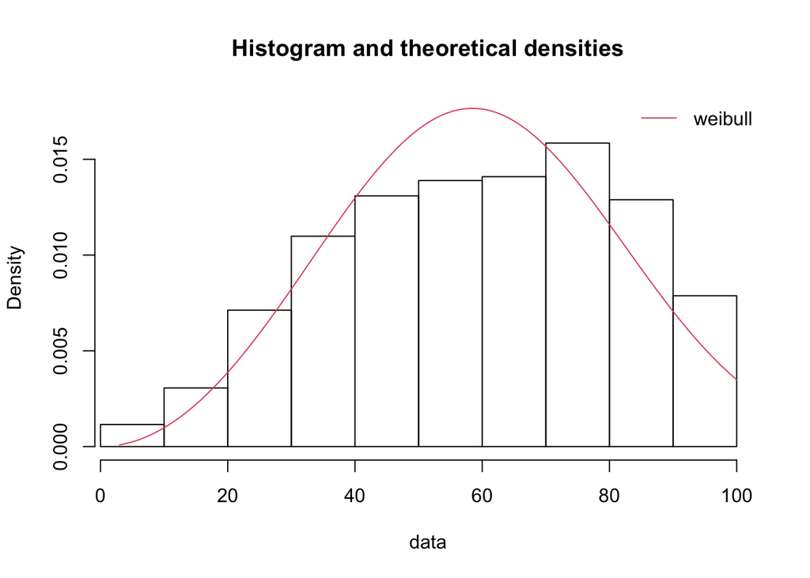

   ```r
   #Relative Frequency Plot and Theoretical Distribution
   denscomp(list(fit_w))
   ```

2. Danceability

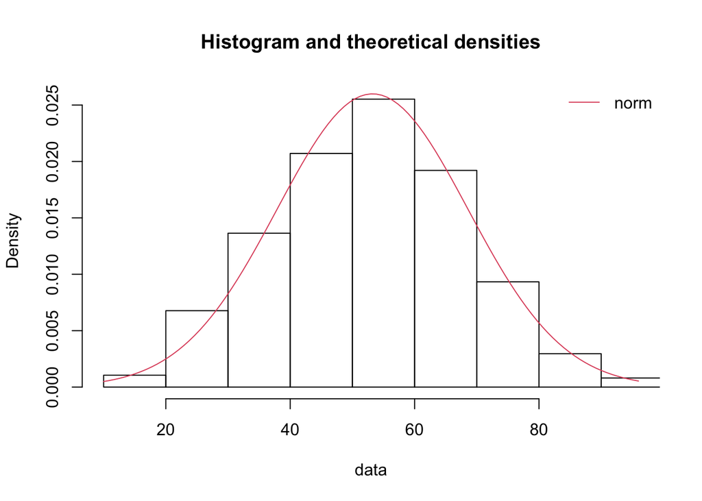

   ```r
   #Relative Frequency Plot and Theoretical Distribution
   denscomp(list(fit_n))
   ```

3. Speechiness

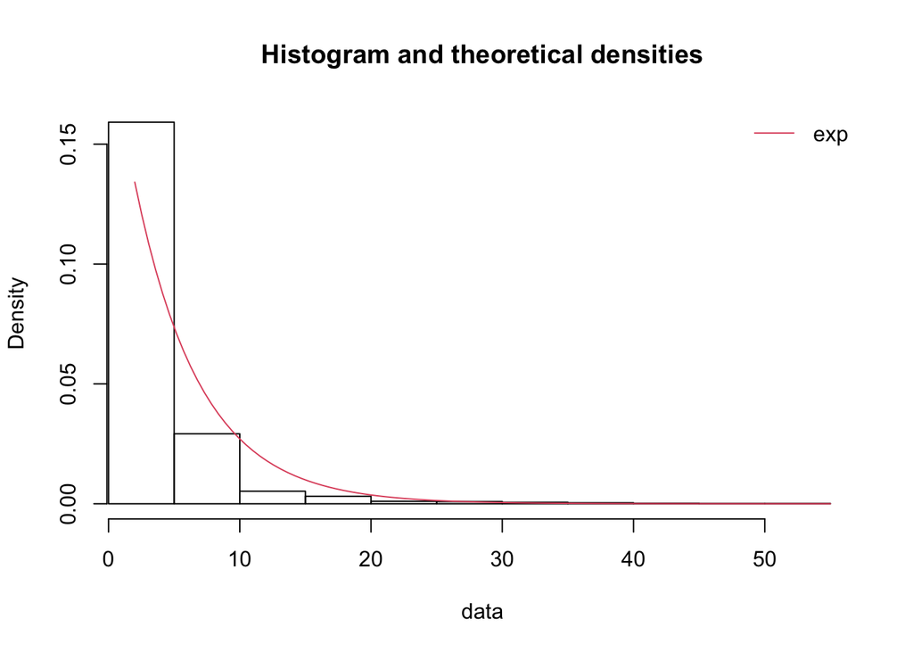

   ```r
   #Relative Frequency Plot and Theoretical Distribution
   denscomp(list(fit_e))
   ```

5. Does it appear that the data fit the distribution well? Justify by comparing the probabilities to the relative frequencies, and the histograms to the theoretical graphs.

   The distribution for Danceability and Speechiness fit the distribution  
   well. This can be seen in the above plots, where the histogram follows  
   the normal and exponential theoretical functions well. The Energy  
   distribution does not fit the weibull distribution as well as the other  
   two variables with their respective theoretical distributions. This can  
   be seen in the distribution plots, where the peaks of the two do not  
   line up. In this situation, we could adjust the shape and scale  
   parameters to better fit the distribution.

**5. CLT**

Use a random number generator to pick N samples of size n from the original data set, where N = 10, 100, 500 and n = 2, 5, 10. Analysis for 5 will be focused on the energy variable in this data set.

1. Computed Average $\overline{x}$
1. n = 2, N = 10

   ```r
   # Random Sample Generator for Energy
   s_means_energy2_10 <- df %>%
     rep_sample_n(size = 2, reps = 10, replace = TRUE) %>%
     summarise(x_bar_energy = mean(Energy))

   # Compute Average x_bar for Energy
   mean(s_means_energy2_10$x_bar_energy)
   ```

   ```
   ## [1] 62.6
   ```

2. n = 2, N = 100

   ```r
   # Random Sample Generator for Energy
   s_means_energy2_100 <- df %>%
     rep_sample_n(size = 2, reps = 100, replace = TRUE) %>%
     summarise(x_bar_energy = mean(Energy))

   # Compute Average x_bar for Energy
   mean(s_means_energy2_100$x_bar_energy)
   ```

   ```
   ## [1] 58.12
   ```

3. n = 2, N = 500

   ```r
   # Random Sample Generator for Energy
   s_means_energy2_500 <- df %>%
     rep_sample_n(size = 2, reps = 500, replace = TRUE) %>%
     summarise(x_bar_energy = mean(Energy))

   # Compute Average x_bar for Energy
   mean(s_means_energy2_500$x_bar_energy)
   ```

   ```
   ## [1] 59.747
   ```

4. n = 5, N = 10

   ```r
   # Random Sample Generator for Energy
   s_means_energy5_10 <- df %>%
     rep_sample_n(size = 5, reps = 10, replace = TRUE) %>%
     summarise(x_bar_energy = mean(Energy))

   # Compute Average x_bar for Energy
   mean(s_means_energy5_10$x_bar_energy)
   ```

   ```
   ## [1] 57.54
   ```

5. n = 5, N = 100

   ```r
   # Random Sample Generator for Energy
   s_means_energy5_100 <- df %>%
     rep_sample_n(size = 5, reps = 100, replace = TRUE) %>%
     summarise(x_bar_energy = mean(Energy))

   # Compute Average x_bar for Energy
   mean(s_means_energy5_100$x_bar_energy)
   ```

   ```
   ## [1] 58.928
   ```

6. n = 5, N = 500

   ```r
   # Random Sample Generator for Energy
   s_means_energy5_500 <- df %>%
     rep_sample_n(size = 5, reps = 500, replace = TRUE) %>%
     summarise(x_bar_energy = mean(Energy))

   # Compute Average x_bar for Energy
   mean(s_means_energy5_500$x_bar_energy)
   ```

   ```
   ## [1] 60.6692
   ```

7. n = 10, N = 10

   ```r
   # Random Sample Generator for Energy
   s_means_energy10_10 <- df %>%
     rep_sample_n(size = 10, reps = 10, replace = TRUE) %>%
     summarise(x_bar_energy = mean(Energy))

   # Compute Average x_bar for Energy
   mean(s_means_energy10_10$x_bar_energy)
   ```

   ```
   ## [1] 55.48
   ```

8. n = 10, N = 100

   ```r
   # Random Sample Generator for Energy
   s_means_energy10_100 <- df %>%
     rep_sample_n(size = 10, reps = 100, replace = TRUE) %>%
     summarise(x_bar_energy = mean(Energy))

   # Compute Average x_bar for Energy
   mean(s_means_energy10_100$x_bar_energy)
   ```

   ```
   ## [1] 58.954
   ```

9. n = 10, N = 500

   ```r
   # Random Sample Generator for Energy
   s_means_energy10_500 <- df %>%
     rep_sample_n(size = 10, reps = 500, replace = TRUE) %>%
     summarise(x_bar_energy = mean(Energy))

   # Compute Average x_bar for Energy
   mean(s_means_energy10_500$x_bar_energy)
   ```

   ```
   ## [1] 59.491
   ```

2. Based on the mean and standard deviation from the original data, state the approximate theoretical distribution of $\overline{x}$.

3. Histograms of $\overline{x}$
1. n = 2, N = 10

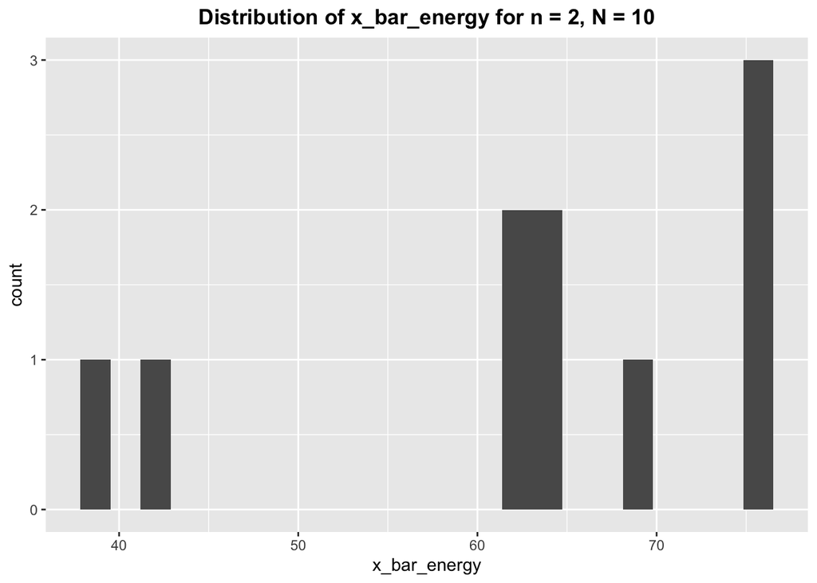

   ```r
   # Histogram of x_bar_energy
   ggplot(data = s_means_energy2_10, aes(x = x_bar_energy)) +
     geom_histogram(bins = 23) +
     ggtitle("Distribution of x_bar_energy for n = 2, N = 10") +
     theme(plot.title = element_text(hjust = 0.5)) +
     theme(plot.title = element_text(face="bold"))
   ```

2. n = 2, N = 100

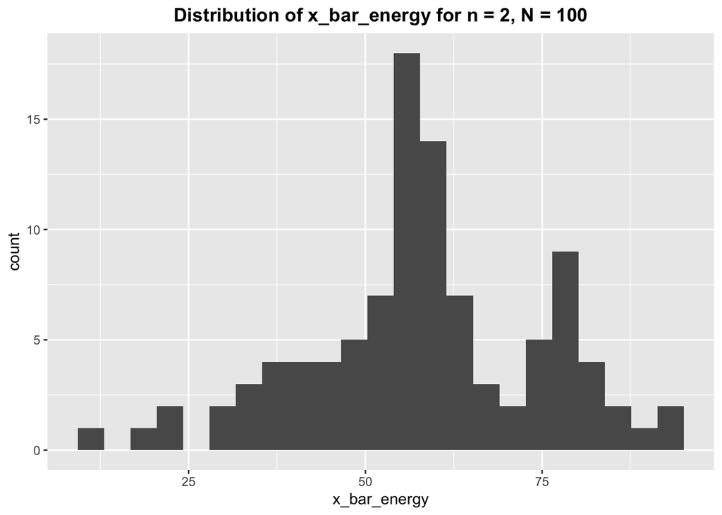

   ```r
   # Histogram of x_bar_energy
   ggplot(data = s_means_energy2_100, aes(x = x_bar_energy)) +
     geom_histogram(bins = 23) +
     ggtitle("Distribution of x_bar_energy for n = 2, N = 100") +
     theme(plot.title = element_text(hjust = 0.5)) +
     theme(plot.title = element_text(face="bold"))
   ```

3. n = 2, N = 500

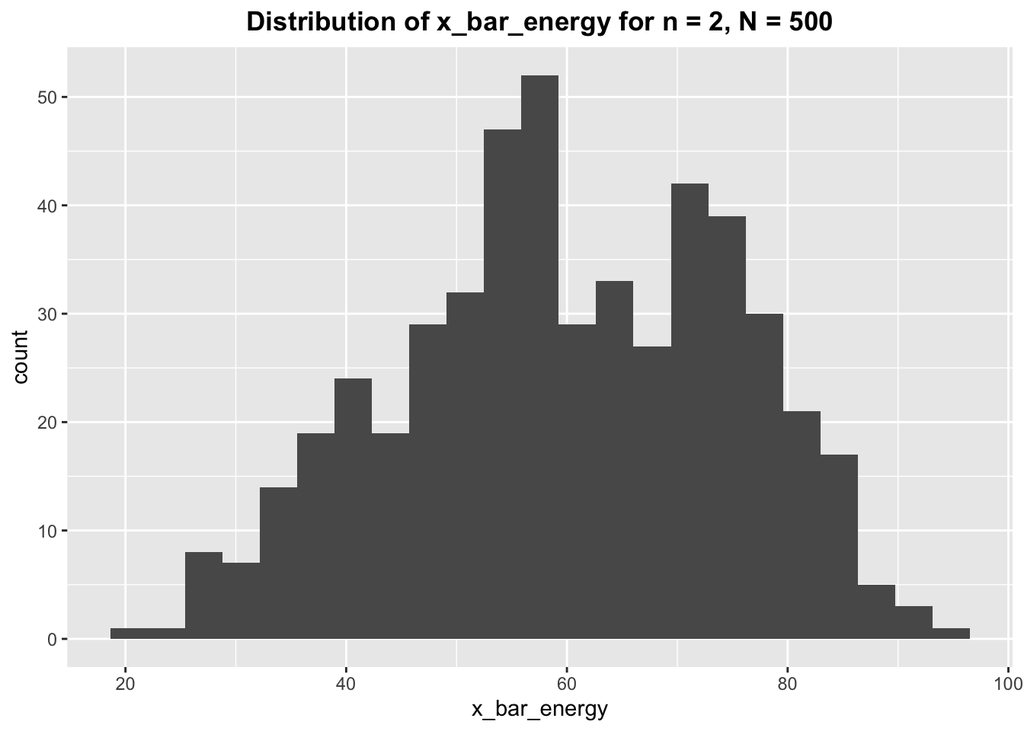

   ```r
   # Histogram of x_bar_energy
   ggplot(data = s_means_energy2_500, aes(x = x_bar_energy)) +
     geom_histogram(bins = 23) +
     ggtitle("Distribution of x_bar_energy for n = 2, N = 500") +
     theme(plot.title = element_text(hjust = 0.5)) +
     theme(plot.title = element_text(face="bold"))
   ```

4. n = 5, N = 10

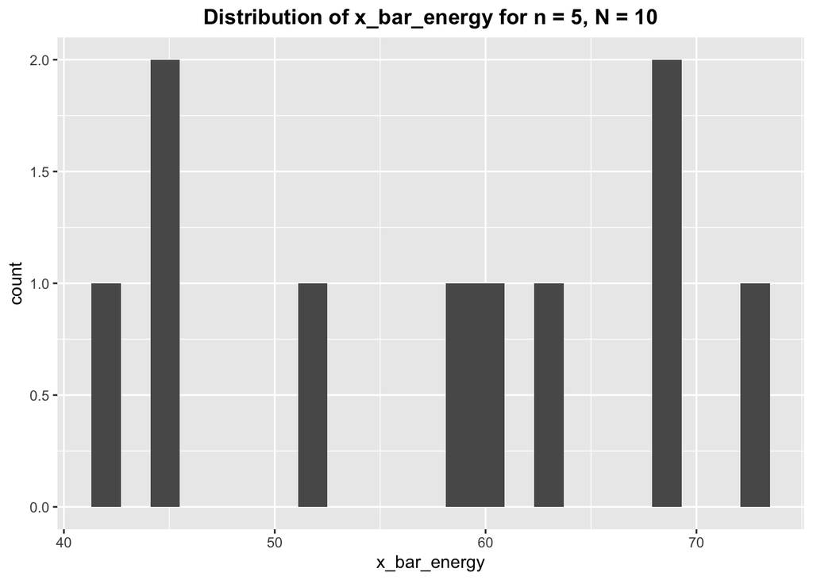

   ```r
   # Histogram of x_bar_energy
   ggplot(data = s_means_energy5_10, aes(x = x_bar_energy)) +
     geom_histogram(bins = 23) +
     ggtitle("Distribution of x_bar_energy for n = 5, N = 10") +
     theme(plot.title = element_text(hjust = 0.5)) +
     theme(plot.title = element_text(face="bold"))
   ```

5. n = 5, N = 100

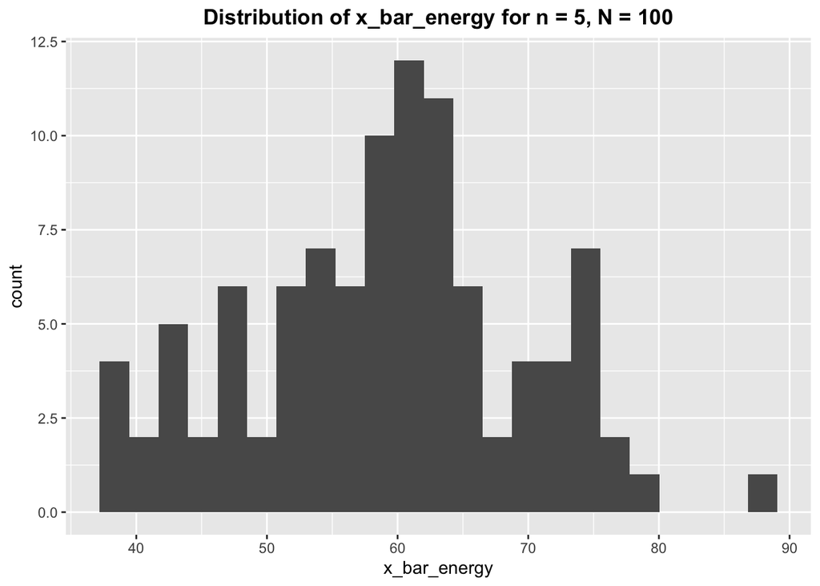

   ```r
   # Histogram of x_bar_energy
   ggplot(data = s_means_energy5_100, aes(x = x_bar_energy)) +
     geom_histogram(bins = 23) +
     ggtitle("Distribution of x_bar_energy for n = 5, N = 100") +
     theme(plot.title = element_text(hjust = 0.5)) +
     theme(plot.title = element_text(face="bold"))
   ```

6. n = 5, N = 500

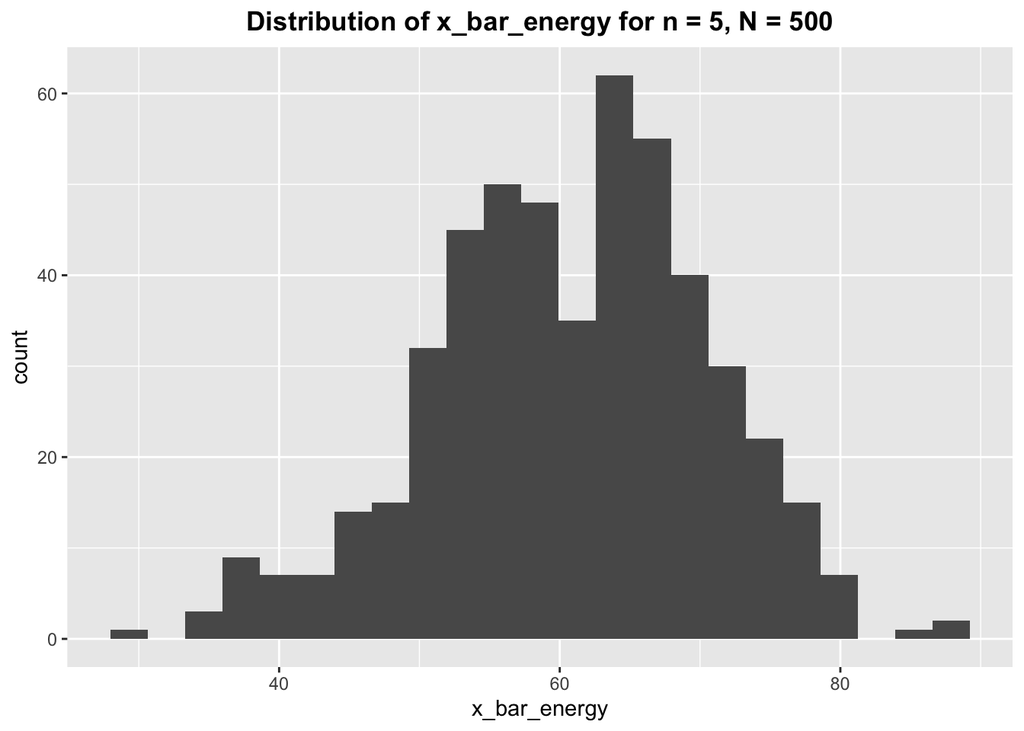

   ```r
   # Histogram of x_bar_energy
   ggplot(data = s_means_energy5_500, aes(x = x_bar_energy)) +
     geom_histogram(bins = 23) +
     ggtitle("Distribution of x_bar_energy for n = 5, N = 500") +
     theme(plot.title = element_text(hjust = 0.5)) +
     theme(plot.title = element_text(face="bold"))
   ```

7. n = 10, N = 10

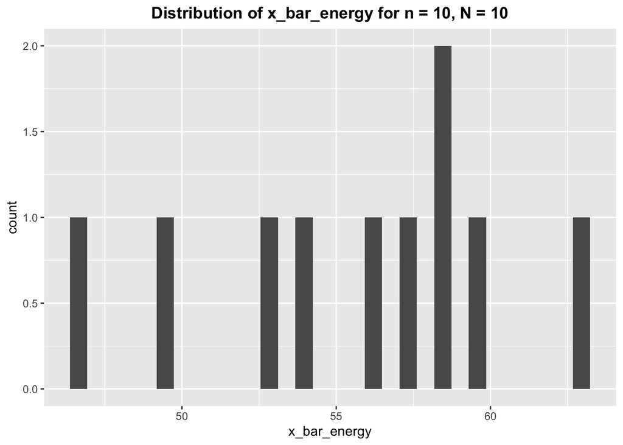

   ```r
   # Histogram of x_bar_energy
   ggplot(data = s_means_energy10_10, aes(x = x_bar_energy)) +
     geom_histogram() +
     ggtitle("Distribution of x_bar_energy for n = 10, N = 10") +
     theme(plot.title = element_text(hjust = 0.5)) +
     theme(plot.title = element_text(face="bold"))
   ```

8. n = 10, N = 100

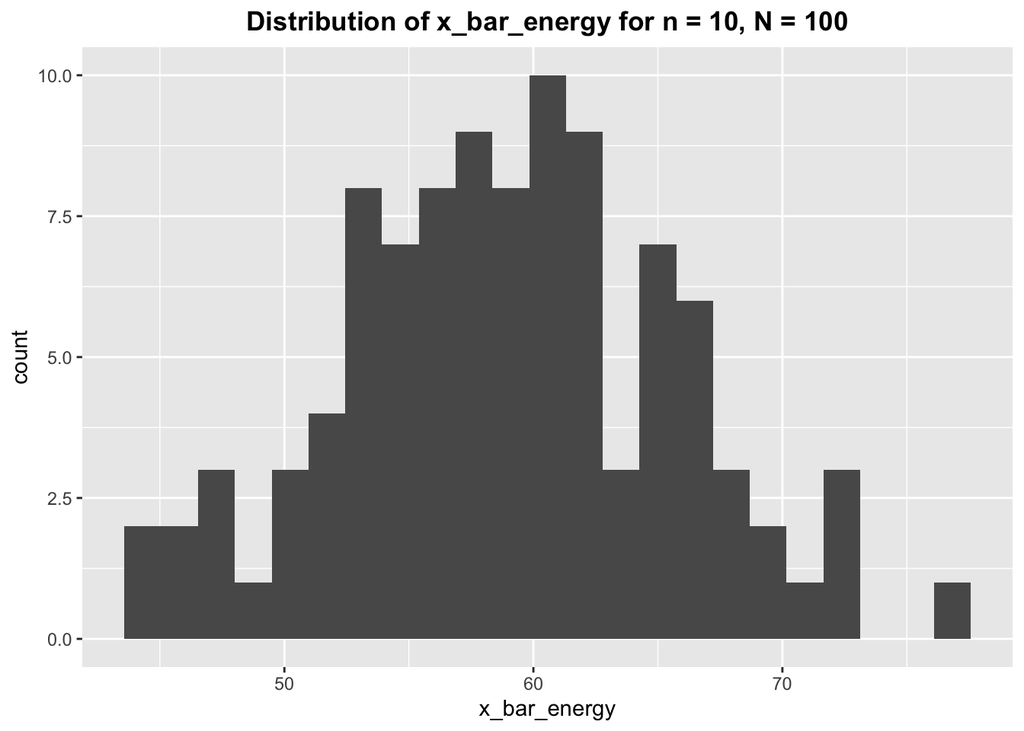

   ```r
   # Histogram of x_bar_energy
   ggplot(data = s_means_energy10_100, aes(x = x_bar_energy)) +
     geom_histogram(bins = 23) +
     ggtitle("Distribution of x_bar_energy for n = 10, N = 100") +
     theme(plot.title = element_text(hjust = 0.5)) +
     theme(plot.title = element_text(face="bold"))
   ```

9. n = 10, N = 500

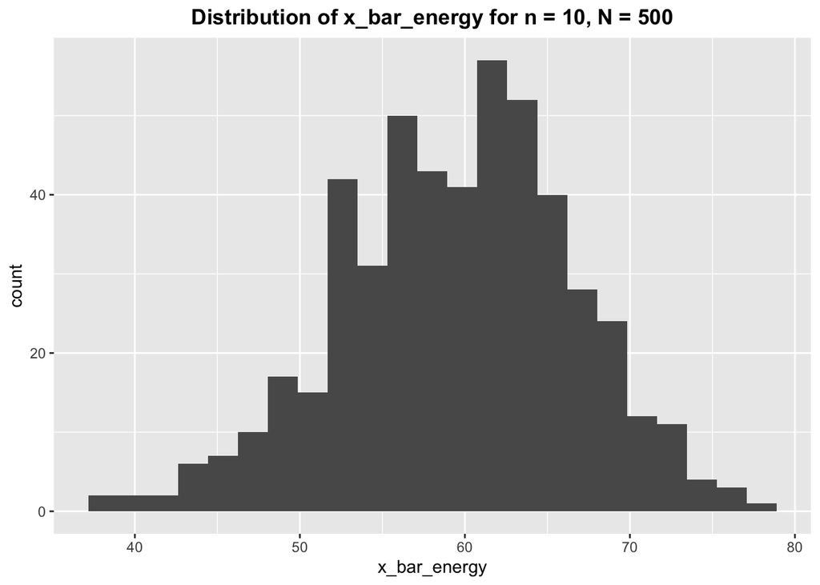

   ```r
   # Histogram of x_bar_energy
   ggplot(data = s_means_energy10_500, aes(x = x_bar_energy)) +
     geom_histogram(bins = 23) +
     ggtitle("Distribution of x_bar_energy for n = 10, N = 500") +
     theme(plot.title = element_text(hjust = 0.5)) +
     theme(plot.title = element_text(face="bold"))
   ```

4. Draw the graph of the theoretical distribution of $\overline{x}$ and compare the relative frequencies to the probabilities. Are the values close?

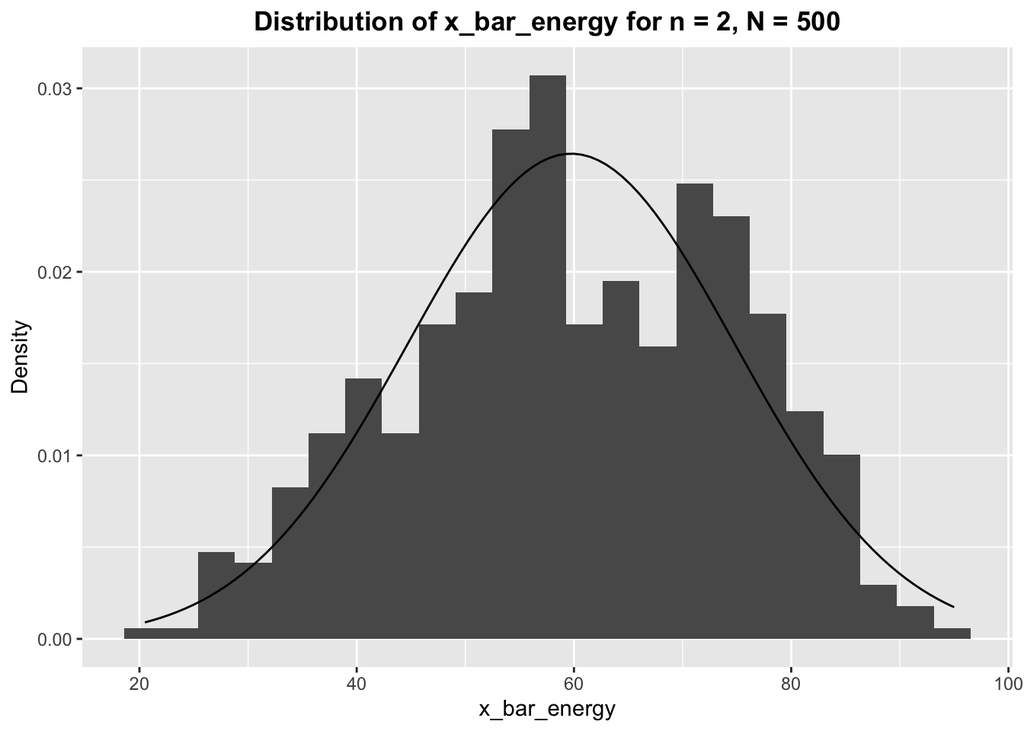

```r
#Relative Frequency Plot for n = 2, N = 500
ggplot(data = s_means_energy2_500, aes(x = x_bar_energy)) +
  geom_histogram(aes(y=..density..) ,bins = 23) +
  ggtitle("Distribution of x_bar_energy for n = 2, N = 500") +
  theme(plot.title = element_text(hjust = 0.5)) +
  theme(plot.title = element_text(face="bold")) +
  ylab("Density") +
  stat_function(fun = dnorm, args = list(mean = mean(s_means_energy2_500$x_bar_energy), sd = sd(s_means_energy2_500$x_bar_energy)))
```

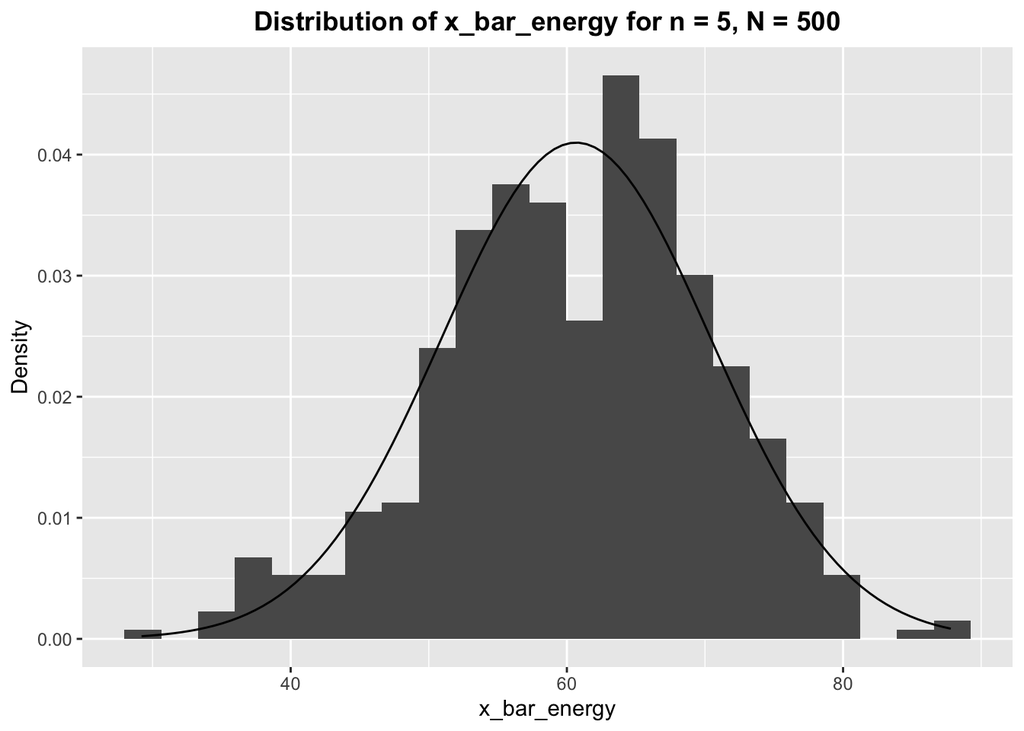

```r
#Relative Frequency Plot for n = 5, N = 500
ggplot(data = s_means_energy5_500, aes(x = x_bar_energy)) +
  geom_histogram(aes(y=..density..) ,bins = 23) +
  ggtitle("Distribution of x_bar_energy for n = 5, N = 500") +
  theme(plot.title = element_text(hjust = 0.5)) +
  theme(plot.title = element_text(face="bold")) +
  ylab("Density") +
  stat_function(fun = dnorm, args = list(mean = mean(s_means_energy5_500$x_bar_energy), sd = sd(s_means_energy5_500$x_bar_energy)))
```

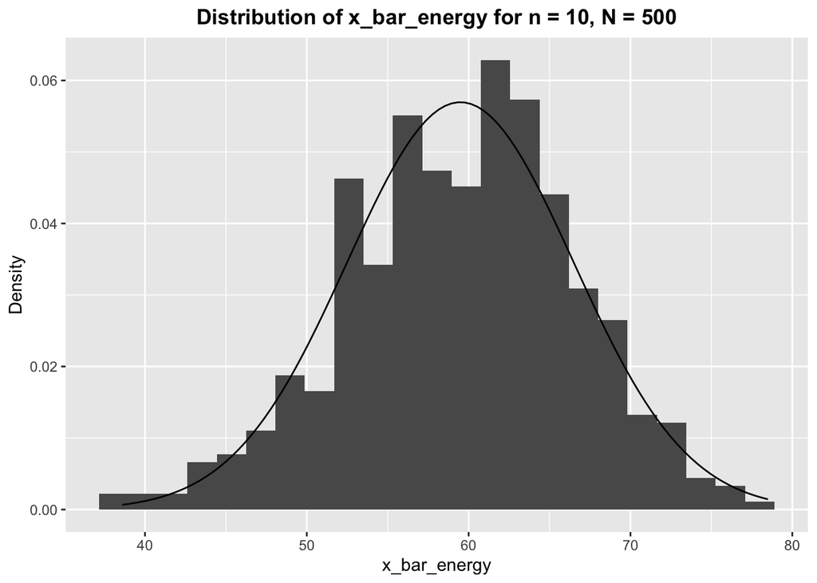

```r
#Relative Frequency Plot for n = 10, N = 500
ggplot(data = s_means_energy10_500, aes(x = x_bar_energy)) +
  geom_histogram(aes(y=..density..) ,bins = 23) +
  ggtitle("Distribution of x_bar_energy for n = 10, N = 500") +
  theme(plot.title = element_text(hjust = 0.5)) +
  theme(plot.title = element_text(face="bold")) +
  ylab("Density") +
  stat_function(fun = dnorm, args = list(mean = mean(s_means_energy10_500$x_bar_energy), sd = sd(s_means_energy10_500$x_bar_energy)))
```

5. Does it appear that the data of averages fit the distribution of x_bar well?

   When the sample number is large enough, we can approximate the x_bar  
   distributions as normal. As seen in the relative frequency histograms  
   with the theoretical normal plots, we can see that the shape fits  
   approximately. The n = 10, N = 500 plot is closer to fitting the normal  
   curve due to the larger sample size.

Additional Questions: What happened to the shape and distribution when the data was averaged? In theory, what should have happened? In theory, would it always happen? Why or why not?

When the data was averaged, the shape and distribution became closer and  
closer to the normal distribution, as the sample number increased. In  
theory, this should be expected due to the Central Limit Theorem (CLT),  
which states that if you have a population and take a sufficiently large  
random samples from the population, then the distribution of the sample  
means will be approximately normal, even if the population distribution  
is not. However, this does not occur in all cases, because the CLT has  
assumptions that are required for this property of sample means to  
approximate as normal distributions to hold true. These assumptions are:  
the data must be sampled randomly, samples should be independent of each  
other, sample size should not be more than 10% of the population when  
sampling is done without replacement, and the sample size should be  
sufficiently large (in general, n >= 30).

**6. Relationship between two variables**

Variables

Valence - The higher the value, the more positive the song  
Beats  
Per Minute (BPM) -The tempo of the song

1. Scatter Plot of Valence and BPM

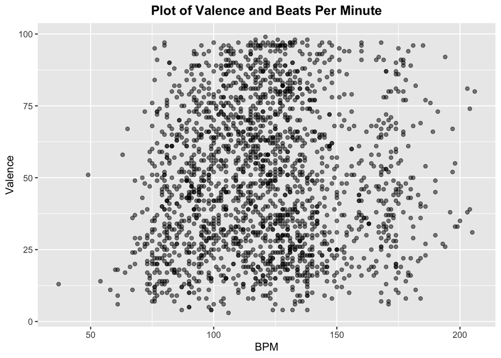

```r
#Rename Beats Per Minute column to BPM for ease of coding
names(df)[names(df)=="Beats.Per.Minute..BPM."] <- "BPM"

#Scatter plot of Valence and BPM
ggplot(df, aes(x = BPM, y = Valence)) +
  geom_point(alpha = 0.5) +
  ggtitle("Plot of Valence and Beats Per Minute") +
  theme(plot.title = element_text(hjust = 0.5)) +
  theme(plot.title = element_text(face="bold"))
```

2. Sample correlation coefficient using entire data set

```r
#Sample Correlation Coefficient
r <- cov(df$BPM, df$Valence)/(sd(df$BPM)*sd(df$Valence))
r
```

```
## [1] 0.05965322
```

3. Estimate 95% CI for the correlation coefficient

```r
# Critical Value for 95% CI
z_star_95 <- qnorm(0.975)

# Calculation for the CI for the correlation coefficient
z_r <- log((1+r)/(1-r)) / 2
L <- z_r - (z_star_95 / sqrt(nrow(df)-3))
U <- z_r + (z_star_95 / sqrt(nrow(df)-3))
lower <- (exp(2*L)-1)/(exp(2*L)+1)
upper <- (exp(2*U)-1)/(exp(2*U)+1)
CI <- data.frame(lower,upper)
CI
```

```
##        lower     upper
## 1 0.01579775 0.1032796
```

4. Chi-Square Test of Independence

Null Hypothesis: There is no association between Valence and BPM  
Alternative Hypothesis: There is an association between Valence and BPM  
Significance Level: 0.05

```r
#Chi-Square Test for BPM and Valence
chisq.test(df$BPM, df$Valence, correct = FALSE, simulate.p.value=TRUE)
```

```
##
##  Pearson's Chi-squared test with simulated p-value (based on 2000
##  replicates)
##
## data:  df$BPM and df$Valence
## X-squared = 13807, df = NA, p-value = 0.4443
```

**7. Categorical Variable, Box Plot, Hypothesis Test**

Variables of Interest:

1. Categorical Variable - Year (Release year of song)
2. Popularity - The higher the value, the more popular the song is
1. Box Plot & Discussion

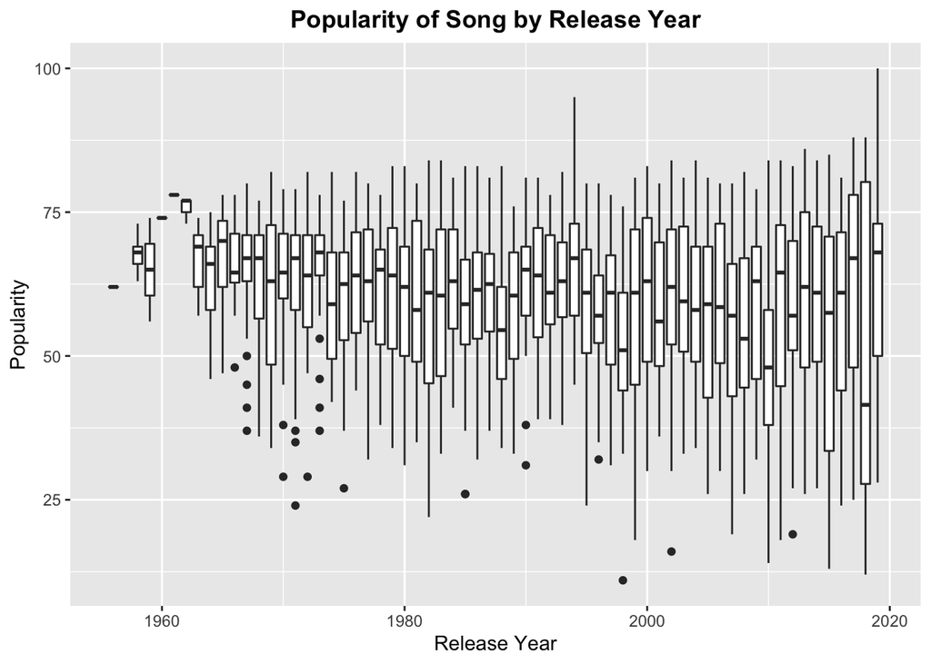

```r
#Box Plot of Popularity by Year
ggplot(df, aes(y = Popularity, x = Year, group = Year)) +
  geom_boxplot() +
  xlab("Release Year") +
  ylab("Popularity") +
  ggtitle("Popularity of Song by Release Year") +
  theme(plot.title = element_text(hjust = 0.5)) +
  theme(plot.title = element_text(face="bold"))
```

The box plots allow us to visually see if there are outliers of popularity within each Year category, as seen by the black dots. There are only outliers outside of the lower 1.5IQR bound. The box plots also increase in range with increasing year, which may be caused by several factors. For example, later years may have more data points, thus having a higher chance of having a larger range or earlier years may have songs that consistently have a popularity within a certain range.

2. Hypothesis Testing

   Question: Is the average popularity of recent songs, defined as those  
   released within the last ten years, different than the average  
   popularity of songs released prior to 10 years ago.  
   Null Hypothesis: There is no difference in the average popularity value  
   between recent and older songs.  
   Alternative Hypothesis: There is a difference in the average popularity  
   value between recent and old songs.  
   Significance Level: 0.05

```r
#Adding a column, stratifying songs as recent or not recent based on whether it was released within the last 10 years.
df <- df %>%
  mutate(Recent = case_when(
    Year > 2011 ~ "Recent",
    Year < 2012 ~ "Not Recent"))

#Hypothesis testing with the above parameters and null/alternative hypotheses
inference(y = Popularity, x = Recent, data = df, statistic = "mean", type = "ht", null = 0, alternative = "twosided", method = "theoretical")
```

```
## Response variable: numerical
## Explanatory variable: categorical (2 levels)
## n_Not Recent = 1674, y_bar_Not Recent = 59.9086, s_Not Recent = 13.0307
## n_Recent = 320, y_bar_Recent = 57.5281, s_Recent = 19.7871
## H0: mu_Not Recent =  mu_Recent
## HA: mu_Not Recent != mu_Recent
## t = 2.0681, df = 319
## p_value = 0.0394
```

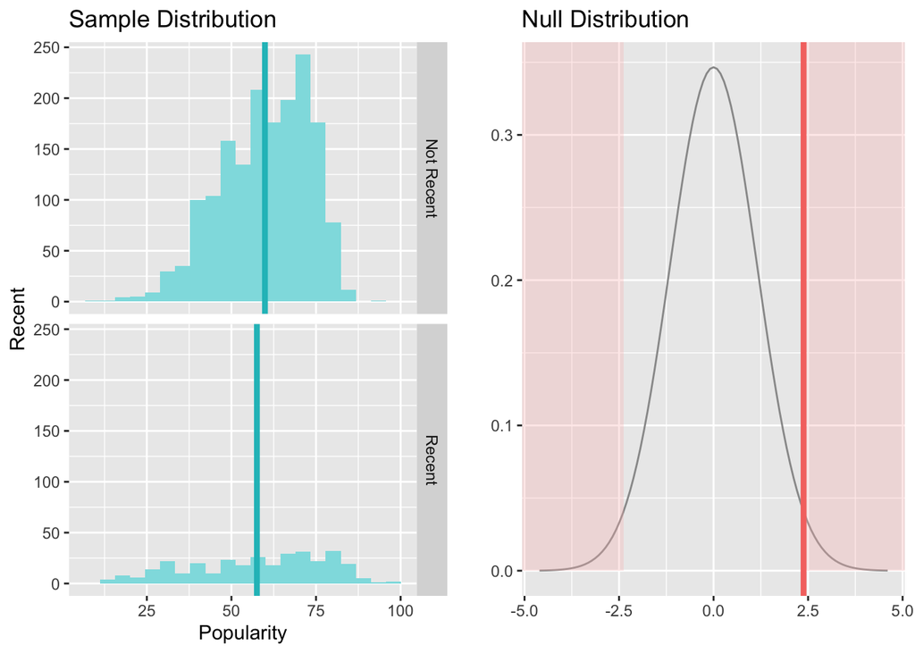

Conclusion: The p-value is 0.0394 which is smaller than alpha = 0.05. This indicates that we can reject the null hypothesis of there being no difference in the average popularity value between recent and older songs.